# Project: Hotel Reservations

- Introduction
- Data Wrangling
- Exploratory Data Analysis
- Split Data
- Train Model
- Conclusions

## Introduction

### Dataset Description

The online hotel reservation channels have dramatically changed booking possibilities and customers’ behavior. A significant number of hotel reservations are called-off due to cancellations or no-shows. The typical reasons for cancellations include change of plans, scheduling conflicts, etc. This is often made easier by the option to do so free of charge or preferably at a low cost which is beneficial to hotel guests but it is a less desirable and possibly revenue-diminishing factor for hotels to deal with. `Can you predict if the customer is going to honor the reservation or cancel it ?`

### Columns Description

##### Attribute of database:

01- `Booking_ID`: unique identifier of each booking  
02- `no_of_adults`: Number of adults  
03- `no_of_children`: Number of Children  
04- `no_of_weekend_nights`: Number of weekend nights (Saturday or Sunday) the guest stayed or booked to stay at the hotel  
05- `no_of_week_nights`: Number of week nights (Monday to Friday) the guest stayed or booked to stay at the hotel  
06- `type_of_meal_plan`: Type of meal plan booked by the customer:  
07- `required_car_parking_space`: Does the customer require a car parking space? (0 - No, 1- Yes)  
08- `room_type_reserved`: Type of room reserved by the customer. The values are ciphered (encoded) by INN Hotels.  
08- `lead_time`: Number of days between the date of booking and the arrival date  
09- `arrival_year`: Year of arrival date  
10- `arrival_month`: Month of arrival date  
11- `arrival_date`: Date of the month  
12- `market_segment_type`: Market segment designation.  
13- `repeated_guest`: Is the customer a repeated guest? (0 - No, 1- Yes)  
14- `no_of_previous_cancellations`: Number of previous bookings that were canceled by the customer prior to the current booking  
15- `no_of_previous_bookings_not_canceled`: Number of previous bookings not canceled by the customer prior to the current booking  
16- `avg_price_per_room`: Average price per day of the reservation; prices of the rooms are dynamic. (in euros)  
17- `no_of_special_requests`: Total number of special requests made by the customer (e.g. high floor, view from the room, etc)  
18- `booking_status`: Flag indicating if the booking was canceled or not.

## Data Wrangling

#### Libraries used

```python
import numpy as np
import pandas as pd
from matplotlib import pyplot as plt
import seaborn as sns
import warnings
warnings.filterwarnings("ignore")
```

#### Read data from csv Hotel Reservations Dataset

```python
data=pd.read_csv('hotel Reservations.csv')
```

#### Show Dataset

```python
data.head()
```

|  | Booking_ID | no_of_adults | no_of_children | no_of_weekend_nights | no_of_week_nights | type_of_meal_plan | required_car_parking_space | room_type_reserved | lead_time | arrival_year | arrival_month | arrival_date | market_segment_type | repeated_guest | no_of_previous_cancellations | no_of_previous_bookings_not_canceled | avg_price_per_room | no_of_special_requests | booking_status |
| --- | --- | --- | --- | --- | --- | --- | --- | --- | --- | --- | --- | --- | --- | --- | --- | --- | --- | --- | --- |
| 0 | INN00001 | 2 | 0 | 1 | 2 | Meal Plan 1 | 0 | Room_Type 1 | 224 | 2017 | 10 | 2 | Offline | 0 | 0 | 0 | 65.00 | 0 | Not_Canceled |
| 1 | INN00002 | 2 | 0 | 2 | 3 | Not Selected | 0 | Room_Type 1 | 5 | 2018 | 11 | 6 | Online | 0 | 0 | 0 | 106.68 | 1 | Not_Canceled |
| 2 | INN00003 | 1 | 0 | 2 | 1 | Meal Plan 1 | 0 | Room_Type 1 | 1 | 2018 | 2 | 28 | Online | 0 | 0 | 0 | 60.00 | 0 | Canceled |
| 3 | INN00004 | 2 | 0 | 0 | 2 | Meal Plan 1 | 0 | Room_Type 1 | 211 | 2018 | 5 | 20 | Online | 0 | 0 | 0 | 100.00 | 0 | Canceled |
| 4 | INN00005 | 2 | 0 | 1 | 1 | Not Selected | 0 | Room_Type 1 | 48 | 2018 | 4 | 11 | Online | 0 | 0 | 0 | 94.50 | 0 | Canceled |

#### Size of data

```python
data.shape
```

```
(36275, 19)
```

### Data Cleaning

> 01- Display columns names and check correct  
> 02- Display dataset info, datatypes, entries count  
> 03- Exploring nulls and remove it  
> 04- Exploring duplicates and remove it  
> 05- Delete Booking_ID

#### 1- Display columns names

```python
def show_columns():
    for i in range(len(data.columns)):
        print(i,data.columns[i])
show_columns()
```

```
0 Booking_ID
1 no_of_adults
2 no_of_children
3 no_of_weekend_nights
4 no_of_week_nights
5 type_of_meal_plan
6 required_car_parking_space
7 room_type_reserved
8 lead_time
9 arrival_year
10 arrival_month
11 arrival_date
12 market_segment_type
13 repeated_guest
14 no_of_previous_cancellations
15 no_of_previous_bookings_not_canceled
16 avg_price_per_room
17 no_of_special_requests
18 booking_status
```

#### 2- Display dataset info, datatypes, entries count

```python
data.info()
```

```
<class 'pandas.core.frame.DataFrame'>
RangeIndex: 36275 entries, 0 to 36274
Data columns (total 19 columns):
 #   Column                                Non-Null Count  Dtype
---  ------                                --------------  -----
 0   Booking_ID                            36275 non-null  object
 1   no_of_adults                          36275 non-null  int64
 2   no_of_children                        36275 non-null  int64
 3   no_of_weekend_nights                  36275 non-null  int64
 4   no_of_week_nights                     36275 non-null  int64
 5   type_of_meal_plan                     36275 non-null  object
 6   required_car_parking_space            36275 non-null  int64
 7   room_type_reserved                    36275 non-null  object
 8   lead_time                             36275 non-null  int64
 9   arrival_year                          36275 non-null  int64
 10  arrival_month                         36275 non-null  int64
 11  arrival_date                          36275 non-null  int64
 12  market_segment_type                   36275 non-null  object
 13  repeated_guest                        36275 non-null  int64
 14  no_of_previous_cancellations          36275 non-null  int64
 15  no_of_previous_bookings_not_canceled  36275 non-null  int64
 16  avg_price_per_room                    36275 non-null  float64
 17  no_of_special_requests                36275 non-null  int64
 18  booking_status                        36275 non-null  object
dtypes: float64(1), int64(13), object(5)
memory usage: 5.3+ MB
```

#### 3- Exploring nulls

```python
data.isnull().sum()
```

```
Booking_ID                              0
no_of_adults                            0
no_of_children                          0
no_of_weekend_nights                    0
no_of_week_nights                       0
type_of_meal_plan                       0
required_car_parking_space              0
room_type_reserved                      0
lead_time                               0
arrival_year                            0
arrival_month                           0
arrival_date                            0
market_segment_type                     0
repeated_guest                          0
no_of_previous_cancellations            0
no_of_previous_bookings_not_canceled    0
avg_price_per_room                      0
no_of_special_requests                  0
booking_status                          0
dtype: int64
```

#### 4- Exploring duplicates

```python
dup=data.duplicated().sum()

if dup ==0:
    print("No duplicated data")
```

```
No duplicated data
```

#### 5- Booking_ID is unique for every row and will not add anything up to the model, but can also decrease its effieciency, so lets remove it.

```python
data.drop(columns=['Booking_ID'],inplace=True)
```

## Exploratory Data Analysis

#### we have two types of data there are numerical and categorical first we will show my numerical data and modify it if we need to this

Numerical Columns

```python
num=data.select_dtypes(['int64','float64']).columns
print("Numerical Columns:")
print("_"*20)
for i,name in enumerate(num):
    print(i+1,name)
```

```
Numerical Columns:
____________________
1 no_of_adults
2 no_of_children
3 no_of_weekend_nights
4 no_of_week_nights
5 required_car_parking_space
6 lead_time
7 arrival_year
8 arrival_month
9 arrival_date
10 repeated_guest
11 no_of_previous_cancellations
12 no_of_previous_bookings_not_canceled
13 avg_price_per_room
14 no_of_special_requests
```

we will describe all rows in columns by Statistical Visualization

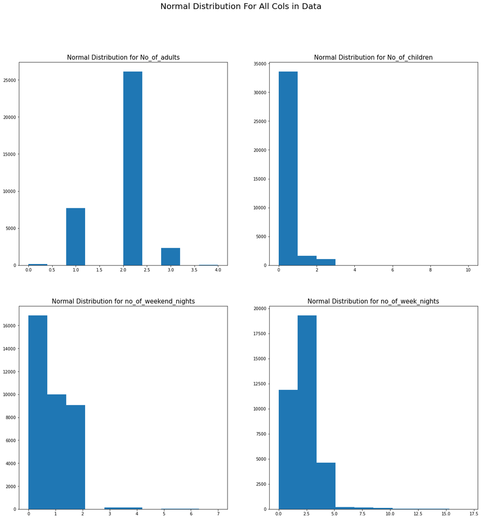

```python
plt.figure(figsize=(20,20))
plt.suptitle("Normal Distribution For All Cols in Data",size=20)

plt.subplot(2,2,1)
plt.title('Normal Distribution for No_of_adults',size=15)
plt.hist(data['no_of_adults'])


#########################################################################
plt.subplot(2,2,2)
plt.title('Normal Distribution for No_of_children',size=15)
plt.hist(data['no_of_children'])


#########################################################################
plt.subplot(2,2,3)
plt.title('Normal Distribution for no_of_weekend_nights',size=15)
plt.hist(data['no_of_weekend_nights'])


#########################################################################
plt.subplot(2,2,4)
plt.title('Normal Distribution for no_of_week_nights',size=15)
plt.hist(data['no_of_week_nights'])



plt.show()
```

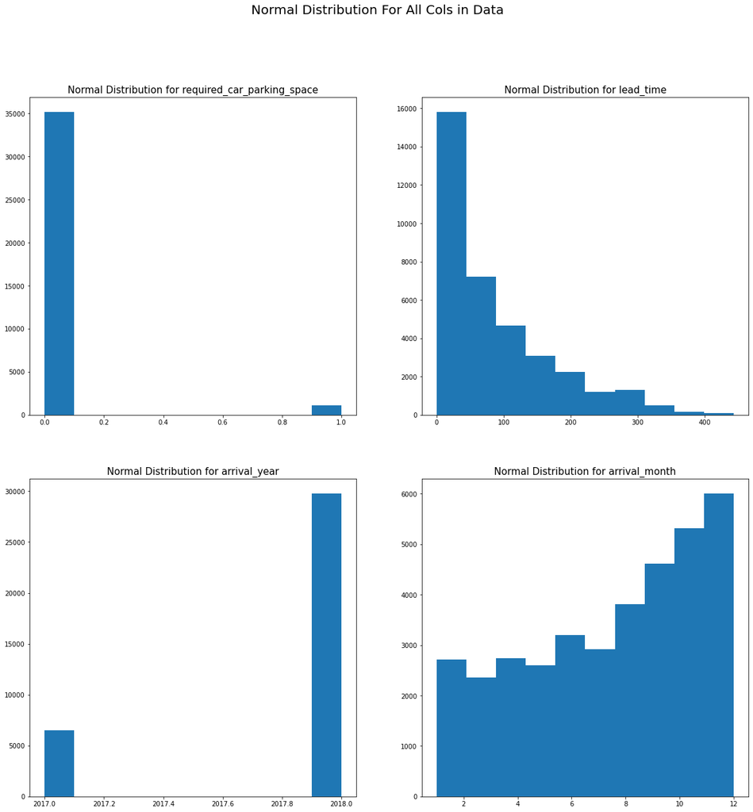

```python
plt.figure(figsize=(20,20))
plt.suptitle("Normal Distribution For All Cols in Data",size=20)

plt.subplot(2,2,1)
plt.title('Normal Distribution for required_car_parking_space',size=15)
plt.hist(data['required_car_parking_space'])


#########################################################################
plt.subplot(2,2,2)
plt.title('Normal Distribution for lead_time',size=15)
plt.hist(data['lead_time'])


#########################################################################
plt.subplot(2,2,3)
plt.title('Normal Distribution for arrival_year',size=15)
plt.hist(data['arrival_year'])


#########################################################################
plt.subplot(2,2,4)
plt.title('Normal Distribution for arrival_month',size=15)
plt.hist(data['arrival_month'])


plt.show()
```

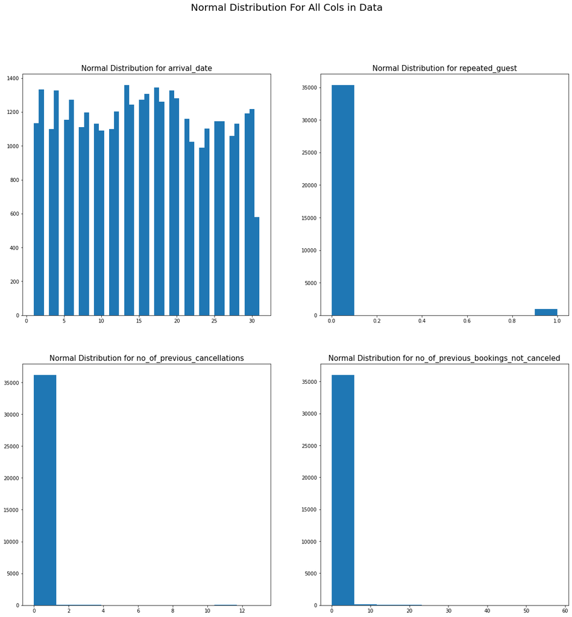

```python
plt.figure(figsize=(20,20))
plt.suptitle("Normal Distribution For All Cols in Data",size=20)

plt.subplot(2,2,1)
plt.title('Normal Distribution for arrival_date',size=15)
plt.hist(data['arrival_date'],bins=45)


#########################################################################
plt.subplot(2,2,2)
plt.title('Normal Distribution for repeated_guest',size=15)
plt.hist(data['repeated_guest'])


#########################################################################
plt.subplot(2,2,3)
plt.title('Normal Distribution for no_of_previous_cancellations',size=15)
plt.hist(data['no_of_previous_cancellations'])


#########################################################################
plt.subplot(2,2,4)
plt.title('Normal Distribution for no_of_previous_bookings_not_canceled',size=15)
plt.hist(data['no_of_previous_bookings_not_canceled'])


plt.show()
```

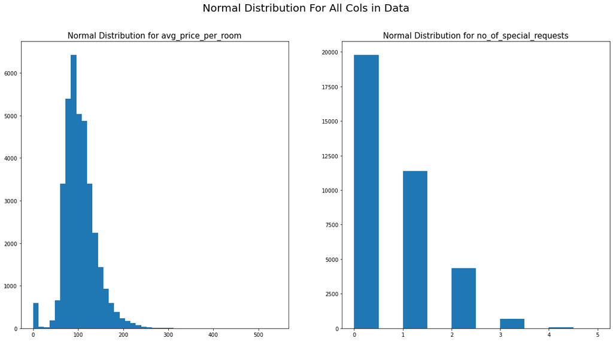

```python
plt.figure(figsize=(20,10))
plt.suptitle("Normal Distribution For All Cols in Data",size=20)

plt.subplot(1,2,1)
plt.title('Normal Distribution for avg_price_per_room',size=15)
plt.hist(data['avg_price_per_room'],bins=45)


#########################################################################
plt.subplot(1,2,2)
plt.title('Normal Distribution for no_of_special_requests',size=15)
plt.hist(data['no_of_special_requests'])



plt.show()
```

As we can see many of the columns are skewed towards the right, if we transform them a little bit, it may affect our accuracy, so lets give it a try. For right skwed data it is good to use Log Transformer. I used the major transformers in the backend, and found the best reuslts came out with Log Transformer. So we will be going with it

```python
from sklearn.preprocessing import FunctionTransformer
```

Add `Log Transformer` Func

```python
FT=FunctionTransformer(func=np.log1p)
```

```python
data[num]=FT.fit_transform(data[num])
```

```python
data.head()
```

|  | no_of_adults | no_of_children | no_of_weekend_nights | no_of_week_nights | type_of_meal_plan | required_car_parking_space | room_type_reserved | lead_time | arrival_year | arrival_month | arrival_date | market_segment_type | repeated_guest | no_of_previous_cancellations | no_of_previous_bookings_not_canceled | avg_price_per_room | no_of_special_requests | booking_status |
| --- | --- | --- | --- | --- | --- | --- | --- | --- | --- | --- | --- | --- | --- | --- | --- | --- | --- | --- |
| 0 | 1.098612 | 0.0 | 0.693147 | 1.098612 | Meal Plan 1 | 0.0 | Room_Type 1 | 5.416100 | 7.609862 | 2.397895 | 1.098612 | Offline | 0.0 | 0.0 | 0.0 | 4.189655 | 0.000000 | Not_Canceled |
| 1 | 1.098612 | 0.0 | 1.098612 | 1.386294 | Not Selected | 0.0 | Room_Type 1 | 1.791759 | 7.610358 | 2.484907 | 1.945910 | Online | 0.0 | 0.0 | 0.0 | 4.679164 | 0.693147 | Not_Canceled |
| 2 | 0.693147 | 0.0 | 1.098612 | 0.693147 | Meal Plan 1 | 0.0 | Room_Type 1 | 0.693147 | 7.610358 | 1.098612 | 3.367296 | Online | 0.0 | 0.0 | 0.0 | 4.110874 | 0.000000 | Canceled |
| 3 | 1.098612 | 0.0 | 0.000000 | 1.098612 | Meal Plan 1 | 0.0 | Room_Type 1 | 5.356586 | 7.610358 | 1.791759 | 3.044522 | Online | 0.0 | 0.0 | 0.0 | 4.615121 | 0.000000 | Canceled |
| 4 | 1.098612 | 0.0 | 0.693147 | 0.693147 | Not Selected | 0.0 | Room_Type 1 | 3.891820 | 7.610358 | 1.609438 | 2.484907 | Online | 0.0 | 0.0 | 0.0 | 4.559126 | 0.000000 | Canceled |

#### Convert Catigorical Columns To Numerical Type

Categroical Columns

```python
cat=data.select_dtypes('object').columns
print("Categorical Columns:")
print("_"*20)
for i,name in enumerate(cat):
    print(i+1,name)
```

```
Categorical Columns:
____________________
1 type_of_meal_plan
2 room_type_reserved
3 market_segment_type
4 booking_status
```

show values inside every categorical columns

```python
Meal_count=data['type_of_meal_plan'].value_counts()
Room_count=data['room_type_reserved'].value_counts()
market_count=data['market_segment_type'].value_counts()
BS_count=data['booking_status'].value_counts()
```

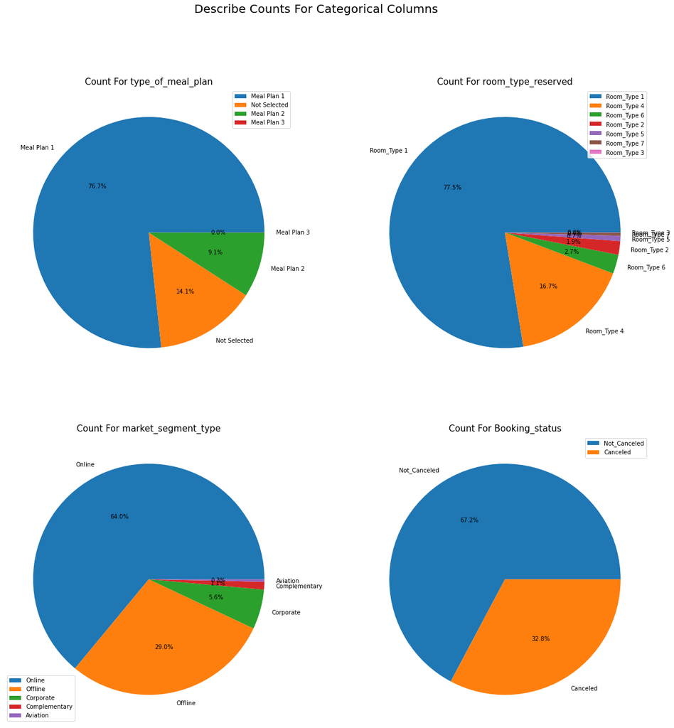

```python
plt.figure(figsize=(20,20))
plt.suptitle("Describe Counts For Categorical Columns",size=20)

plt.subplot(2,2,1)
plt.title('Count For type_of_meal_plan',size=15)
plt.pie(Meal_count,
        labels=Meal_count.index,
        autopct='%.1f%%')

plt.legend()
#########################################################################
plt.subplot(2,2,2)
plt.title('Count For room_type_reserved',size=15)
plt.pie(Room_count,
        labels=Room_count.index,
        autopct='%.1f%%')
plt.legend()
#########################################################################
plt.subplot(2,2,3)
plt.title('Count For market_segment_type',size=15)
plt.pie(market_count,
        labels=market_count.index,
        autopct='%.1f%%')
plt.legend()
#########################################################################
plt.subplot(2,2,4)
plt.title('Count For Booking_status',size=15)
plt.pie(BS_count,
        labels=BS_count.index,
        autopct='%.1f%%')
plt.legend()
plt.show()
```

As we can see there are several values in the market_segment_type and room_type_reserved that have several values which comprises of only a small portion in the value, these may decrease the efficiency of the model, lets encode the major ones, and put the minor ones into another columns

- Convert room type 5 ,7,3 to room_Type_other because have small count

```python
cons=690
indx_rtr = data["room_type_reserved"].value_counts()[data["room_type_reserved"].value_counts() <= cons].index
rtr=pd.get_dummies(data['room_type_reserved'].replace(indx_rtr,'room_type_other'))
```

- Convert market_segment_type Complementary,Aviation to market_type_other because have small count

```python
cons=2000
indx_mst = data["market_segment_type"].value_counts()[data["market_segment_type"].value_counts() <= cons].index
mst=pd.get_dummies(data['market_segment_type'].replace(indx_mst,'market_type_other'))
```

- Convert column type_of_meal_plan to numerical multicolumns

```python
tomp=pd.get_dummies(data['type_of_meal_plan'])
```

Now we don't need columns `market_segment_type`, `room_type_reserved` and `type_of_meal_plan` we will replace them by `rtr`, `mst` and `tomp`

```python
data.drop(columns=['market_segment_type','room_type_reserved','type_of_meal_plan'],inplace=True)
```

```python
new_data=pd.concat([rtr,mst,tomp,data],axis=1,join='inner')
```

- Convert Values Of Booking_status From [Not_Canceled - Canceled] To [1 - 0]

```python
new_data['booking_status'].replace({'Not_Canceled':1,
                                'Canceled':0},inplace=True)
```

```python
new_data.head()
```

|  | Room_Type 1 | Room_Type 2 | Room_Type 4 | Room_Type 6 | room_type_other | Corporate | Offline | Online | market_type_other | Meal Plan 1 | ... | lead_time | arrival_year | arrival_month | arrival_date | repeated_guest | no_of_previous_cancellations | no_of_previous_bookings_not_canceled | avg_price_per_room | no_of_special_requests | booking_status |
| --- | --- | --- | --- | --- | --- | --- | --- | --- | --- | --- | --- | --- | --- | --- | --- | --- | --- | --- | --- | --- | --- |
| 0 | 1 | 0 | 0 | 0 | 0 | 0 | 1 | 0 | 0 | 1 | ... | 5.416100 | 7.609862 | 2.397895 | 1.098612 | 0.0 | 0.0 | 0.0 | 4.189655 | 0.000000 | 1 |
| 1 | 1 | 0 | 0 | 0 | 0 | 0 | 0 | 1 | 0 | 0 | ... | 1.791759 | 7.610358 | 2.484907 | 1.945910 | 0.0 | 0.0 | 0.0 | 4.679164 | 0.693147 | 1 |
| 2 | 1 | 0 | 0 | 0 | 0 | 0 | 0 | 1 | 0 | 1 | ... | 0.693147 | 7.610358 | 1.098612 | 3.367296 | 0.0 | 0.0 | 0.0 | 4.110874 | 0.000000 | 0 |
| 3 | 1 | 0 | 0 | 0 | 0 | 0 | 0 | 1 | 0 | 1 | ... | 5.356586 | 7.610358 | 1.791759 | 3.044522 | 0.0 | 0.0 | 0.0 | 4.615121 | 0.000000 | 0 |
| 4 | 1 | 0 | 0 | 0 | 0 | 0 | 0 | 1 | 0 | 0 | ... | 3.891820 | 7.610358 | 1.609438 | 2.484907 | 0.0 | 0.0 | 0.0 | 4.559126 | 0.000000 | 0 |

5 rows × 28 columns

#### We need To Know Correlation Between Booking_Status with every columns

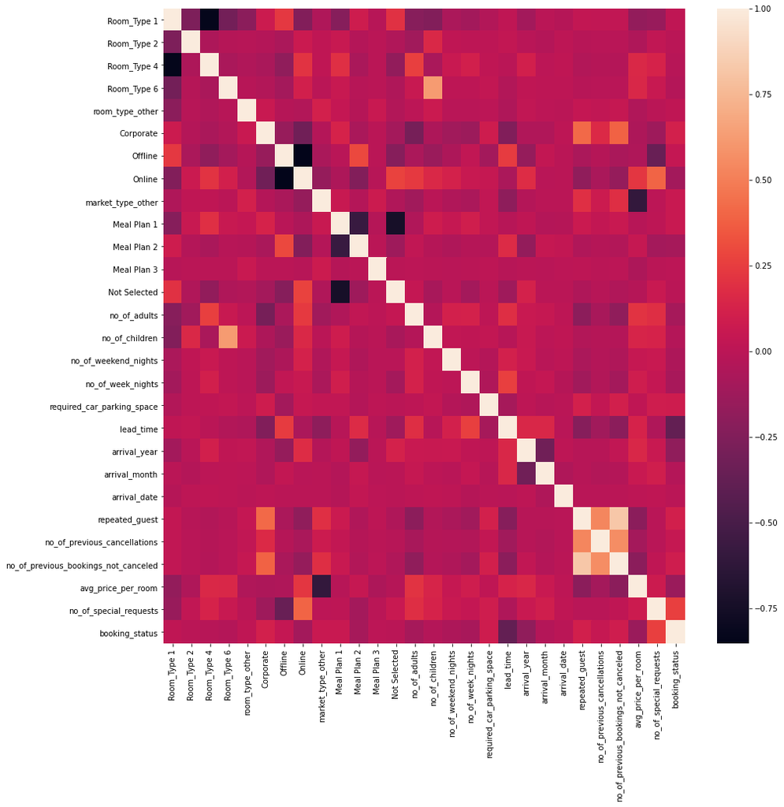

```python
plt.figure(figsize=(15,15))
sns.heatmap(new_data.corr())
```

```python
new_data.corr()['booking_status'].sort_values()
```

```
lead_time                              -0.380871
arrival_year                           -0.179529
avg_price_per_room                     -0.138485
Online                                 -0.106362
no_of_adults                           -0.088393
Meal Plan 2                            -0.086370
no_of_week_nights                      -0.082837
no_of_weekend_nights                   -0.057137
Room_Type 6                            -0.032652
arrival_month                          -0.031963
no_of_children                         -0.031947
Room_Type 4                            -0.013309
arrival_date                           -0.004949
Not Selected                           -0.003072
Room_Type 2                            -0.000548
Meal Plan 3                             0.003193
room_type_other                         0.016760
Room_Type 1                             0.020326
Offline                                 0.038351
no_of_previous_cancellations            0.050026
Meal Plan 1                             0.061267
market_type_other                       0.065502
required_car_parking_space              0.086185
no_of_previous_bookings_not_canceled    0.090965
repeated_guest                          0.107287
Corporate                               0.112993
no_of_special_requests                  0.257632
booking_status                          1.000000
Name: booking_status, dtype: float64
```

```python
new_data.info()
```

```
<class 'pandas.core.frame.DataFrame'>
RangeIndex: 36275 entries, 0 to 36274
Data columns (total 28 columns):
 #   Column                                Non-Null Count  Dtype
---  ------                                --------------  -----
 0   Room_Type 1                           36275 non-null  uint8
 1   Room_Type 2                           36275 non-null  uint8
 2   Room_Type 4                           36275 non-null  uint8
 3   Room_Type 6                           36275 non-null  uint8
 4   room_type_other                       36275 non-null  uint8
 5   Corporate                             36275 non-null  uint8
 6   Offline                               36275 non-null  uint8
 7   Online                                36275 non-null  uint8
 8   market_type_other                     36275 non-null  uint8
 9   Meal Plan 1                           36275 non-null  uint8
```

[output cut: 20 more lines]

my data is ready for training model we will split to X for input, y for output

```python
X=new_data.drop(columns='booking_status')
y=new_data['booking_status']
```

# Split data into train and test sets for model

```python
from sklearn.model_selection import train_test_split
```

```python
X_train,X_test,y_train,y_test=train_test_split(X,y,test_size=0.3,random_state=42)
```

```python
print(f"Train set Size : {len(X_train)}")
print(f"Test set Size : {len(X_test)}")
```

```
Train set Size : 25392
Test set Size : 10883
```

we will convert values for X to make it values in equal range

```python
from sklearn.preprocessing import StandardScaler
```

```python
sc = StandardScaler()
X_train = sc.fit_transform(X_train)
X_test = sc.transform(X_test)
```

# Choose & Train the Model

```python
from sklearn.metrics import accuracy_score,f1_score, classification_report, confusion_matrix, plot_roc_curve,roc_curve,precision_score,recall_score
from sklearn.linear_model import LogisticRegression
from sklearn.ensemble import BaggingClassifier
from sklearn.ensemble import VotingClassifier
from sklearn.tree import DecisionTreeClassifier
from sklearn.svm import SVC
```

Model_No1: LogisticRegression  
Model_No2: DecisionTree  
Model_No3: Support Vector Machine

### Model_No1:LogisticRegression

```python
LR=LogisticRegression()
DTC=DecisionTreeClassifier()
SVC=SVC()
```

```python
LR.fit(X_train,y_train)
DTC.fit(X_train,y_train)
SVC.fit(X_train,y_train)
```

```
SVC()
```

#### Model Predict

```python
y_pred1=LR.predict(X_test)
y_pred2=DTC.predict(X_test)
y_pred3=SVC.predict(X_test)
```

```python
print(f"Original output\t:{y_test.values}")
print("_"*40)
print(f"LR predict output\t:{y_pred1}")
print(f"DTC predict output\t:{y_pred2}")
print(f"SVC predict output\t:{y_pred3}")
```

```
Original output	:[1 1 1 ... 1 0 0]
________________________________________
LR predict output	:[1 1 1 ... 1 0 0]
DTC predict output	:[1 1 1 ... 1 0 0]
SVC predict output	:[1 1 1 ... 1 0 0]
```

#### Model Evaluation

accuracy_score  
f1_score  
precision_score  
recall_score  
classification_report  
confusion_matrix  
ROC CURVE

```python
train_acc=f"{round(LR.score(X_train,y_train),2)*100} %"
acc = f"{round(accuracy_score(y_test,y_pred1),2)*100} %"
f1 = f"{round(f1_score(y_test,y_pred1),2)*100} %"
prec = f"{round(precision_score(y_test,y_pred1),2)*100} %"
rec =  f"{round(recall_score(y_test,y_pred1),2)*100} %"

#________________________________________________________________________

train_acc2=f"{round(DTC.score(X_train,y_train),2)*100} %"
acc2 = f"{round(accuracy_score(y_test,y_pred2),2)*100} %"
f12 = f"{round(f1_score(y_test,y_pred2),2)*100} %"
prec2 = f"{round(precision_score(y_test,y_pred2),2)*100} %"
rec2 =  f"{round(recall_score(y_test,y_pred2),2)*100} %"

#________________________________________________________________________
train_acc3=f"{round(SVC.score(X_train,y_train),2)*100} %"
acc3 = f"{round(accuracy_score(y_test,y_pred3),2)*100} %"
f13 = f"{round(f1_score(y_test,y_pred3),2)*100} %"
prec3 = f"{round(precision_score(y_test,y_pred3),2)*100} %"
rec3 =  f"{round(recall_score(y_test,y_pred3),2)*100} %"


results = pd.DataFrame([['Logistic Regression',train_acc, acc, f1, prec, rec],
                        ['Decision Tree',train_acc2, acc2, f12, prec2, rec2],
                        ['SVC',train_acc3, acc3, f13, prec3, rec3]],
                     columns =  ['Model','Train_Accuracy','Test_Accuracy','F1 score','Precision','Recall'])
results
```

|  | Model | Train_Accuracy | Test_Accuracy | F1 score | Precision | Recall |
| --- | --- | --- | --- | --- | --- | --- |
| 0 | Logistic Regression | 80.0 % | 80.0 % | 86.0 % | 82.0 % | 90.0 % |
| 1 | Decision Tree | 99.0 % | 87.0 % | 90.0 % | 90.0 % | 89.0 % |
| 2 | SVC | 84.0 % | 83.0 % | 88.0 % | 84.0 % | 92.0 % |

```python
print("Report for LR:\n",classification_report(y_test,y_pred1))
print("_"*50)
print("Report for DTC:\n",classification_report(y_test,y_pred2))
print("_"*50)
print("Report for SVC:\n",classification_report(y_test,y_pred3))
```

```
Report for LR:
               precision    recall  f1-score   support

           0       0.75      0.60      0.67      3607
           1       0.82      0.90      0.86      7276

    accuracy                           0.80     10883
   macro avg       0.78      0.75      0.76     10883
weighted avg       0.80      0.80      0.79     10883

__________________________________________________
Report for DTC:
               precision    recall  f1-score   support

           0       0.79      0.81      0.80      3607
           1       0.90      0.90      0.90      7276

    accuracy                           0.87     10883
   macro avg       0.85      0.85      0.85     10883
weighted avg       0.87      0.87      0.87     10883

__________________________________________________
Report for SVC:
               precision    recall  f1-score   support

           0       0.80      0.66      0.72      3607
           1       0.84      0.92      0.88      7276

    accuracy                           0.83     10883
   macro avg       0.82      0.79      0.80     10883
weighted avg       0.83      0.83      0.83     10883
```

```python
con=confusion_matrix(y_test,y_pred1)
con2=confusion_matrix(y_test,y_pred2)
con3=confusion_matrix(y_test,y_pred3)

print('Model LR'.center(70,'_'))
print("Correct Predict :")
print("_"*30)
print(f"number of True Positive : {con[0][0]}")
print(f"number of True Negative : {con[1][1]}")
print("\nIncorrect Predict :")
print("_"*30)
print(f"number of False Positive : {con[0][1]}")
print(f"number of False Negative : {con[1][0]}\n")

print("*"*60)

print('Model DTC'.center(70,'_'))
print("Correct Predict :")
print("_"*30)
print(f"number of True Positive : {con2[0][0]}")
print(f"number of True Negative : {con2[1][1]}")
print("\nIncorrect Predict :")
print("_"*30)
print(f"number of False Positive : {con2[0][1]}")
print(f"number of False Negative : {con2[1][0]}\n")

print("*"*60)

print('Model SVC'.center(70,'_'))
print("Correct Predict :")
print("_"*30)
print(f"number of True Positive : {con3[0][0]}")
print(f"number of True Negative : {con3[1][1]}")
print("\nIncorrect Predict :")
print("_"*30)
print(f"number of False Positive : {con3[0][1]}")
print(f"number of False Negative : {con3[1][0]}")
```

```
_______________________________Model LR_______________________________
Correct Predict :
______________________________
number of True Positive : 2182
number of True Negative : 6530

Incorrect Predict :
______________________________
number of False Positive : 1425
number of False Negative : 746

______________________________Model DTC_______________________________
Correct Predict :
______________________________
number of True Positive : 2908
number of True Negative : 6518

Incorrect Predict :
______________________________
number of False Positive : 699
number of False Negative : 758

______________________________Model SVC_______________________________
Correct Predict :
______________________________
number of True Positive : 2364
number of True Negative : 6673

Incorrect Predict :
______________________________
number of False Positive : 1243
number of False Negative : 603
```

show `ROC CURVE` to explain strength of models

```python
fper1,tper1,th1=roc_curve(y_test,y_pred1)
fper2,tper2,th2=roc_curve(y_test,y_pred2)
fper3,tper3,th3=roc_curve(y_test,y_pred3)
```

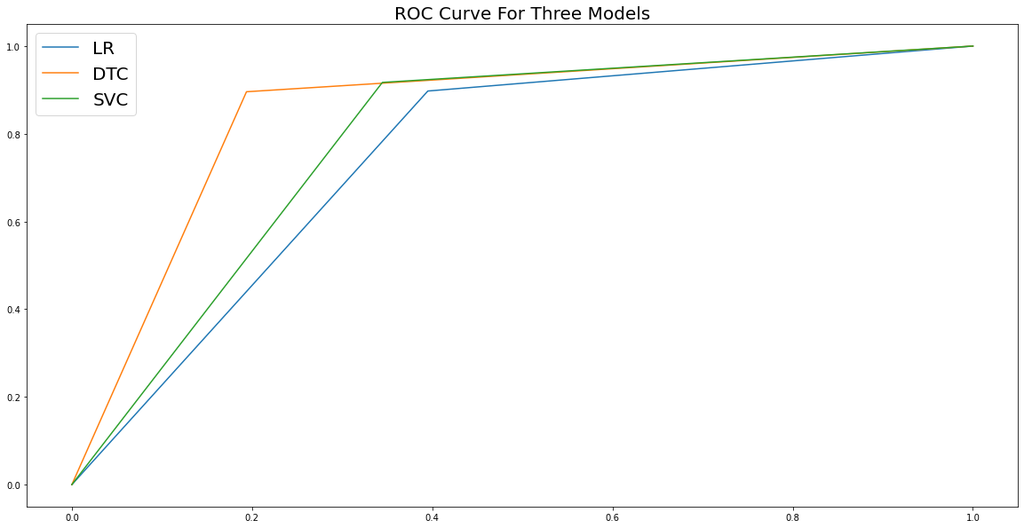

```python
plt.figure(figsize=(20,10))
plt.title("ROC Curve For Three Models",size=20)
plt.plot(fper1,tper1,label='LR')
plt.plot(fper2,tper2,Label='DTC')
plt.plot(fper3,tper3,label='SVC')
plt.legend(prop={'size':20})
plt.show()
```

```python
results
```

[output not shown]

From above we see that all model work will put maybe work best if we use any way from ensembling methods so we will develop my models by two ways. lets do it

use bagging with Decision Tree that have some overfit

### First Way To Develop Three model with Bagging Method

```python
bagging_clf1 = BaggingClassifier(base_estimator=LR, n_estimators=100, random_state=42)
bagging_clf1.fit(X_train, y_train)
```

```
BaggingClassifier(base_estimator=LogisticRegression(), n_estimators=100,
                  random_state=42)
```

```python
bagging_clf2 = BaggingClassifier(base_estimator=DTC, n_estimators=100, random_state=42)
bagging_clf2.fit(X_train, y_train)
```

```
BaggingClassifier(base_estimator=DecisionTreeClassifier(), n_estimators=100,
                  random_state=42)
```

```python
bagging_clf3= BaggingClassifier(base_estimator=SVC, n_estimators=15, random_state=42)
bagging_clf3.fit(X_train, y_train)
```

```
BaggingClassifier(base_estimator=SVC(), n_estimators=15, random_state=42)
```

#### Model Predict

```python
y_pred4=bagging_clf1.predict(X_test)
y_pred5=bagging_clf2.predict(X_test)
y_pred6=bagging_clf3.predict(X_test)
```

```python
print(f"Original output\t:{y_test.values}")
print("_"*40)
print(f"bagging_clf1 predict output\t:{y_pred4}")
print(f"bagging_clf2 predict output\t:{y_pred5}")
print(f"bagging_clf3 predict output\t:{y_pred6}")
```

```
Original output	:[1 1 1 ... 1 0 0]
________________________________________
bagging_clf1 predict output	:[1 1 1 ... 1 0 0]
bagging_clf2 predict output	:[1 1 1 ... 1 0 0]
bagging_clf3 predict output	:[1 1 1 ... 1 0 0]
```

#### Model Evaluation

```python
train_acc4=f"{round(bagging_clf1.score(X_train,y_train),2)*100} %"
acc4 = f"{round(accuracy_score(y_test,y_pred4),2)*100} %"
f14 = f"{round(f1_score(y_test,y_pred4),2)*100} %"
prec4 = f"{round(precision_score(y_test,y_pred1),4)*100} %"
rec4 =  f"{round(recall_score(y_test,y_pred4),2)*100} %"

#________________________________________________________________________

train_acc5=f"{round(bagging_clf2.score(X_train,y_train),2)*100} %"
acc5 = f"{round(accuracy_score(y_test,y_pred5),2)*100} %"
f15= f"{round(f1_score(y_test,y_pred5),2)*100} %"
prec5 = f"{round(precision_score(y_test,y_pred5),2)*100} %"
rec5=  f"{round(recall_score(y_test,y_pred5),2)*100} %"

#________________________________________________________________________
train_acc6=f"{round(bagging_clf3.score(X_train,y_train),2)*100} %"
acc6 = f"{round(accuracy_score(y_test,y_pred6),2)*100} %"
f16= f"{round(f1_score(y_test,y_pred6),2)*100} %"
prec6 = f"{round(precision_score(y_test,y_pred6),2)*100} %"
rec6=  f"{round(recall_score(y_test,y_pred6),2)*100} %"


results2 = pd.DataFrame([['Bagged Logistic Regression',train_acc4, acc4, f14, prec4, rec4],
                        ['Bagged Decision Tree',train_acc5, acc5, f15, prec5, rec5],
                        ['Bagged SVC',train_acc6, acc6, f16, prec6, rec6]],
                     columns =  ['Model','Train_Accuracy','Test_Accuracy','F1 score','Precision','Recall'])
results2
```

|  | Model | Train_Accuracy | Test_Accuracy | F1 score | Precision | Recall |
| --- | --- | --- | --- | --- | --- | --- |
| 0 | Bagged Logistic Regression | 80.0 % | 80.0 % | 86.0 % | 82.09 % | 90.0 % |
| 1 | Bagged Decision Tree | 99.0 % | 90.0 % | 93.0 % | 91.0 % | 94.0 % |
| 2 | Bagged SVC | 84.0 % | 83.0 % | 88.0 % | 84.0 % | 92.0 % |

```python
print("Report for bagging_clf1:\n",classification_report(y_test,y_pred4))
print("_"*50)
print("Report for bagging_clf2:\n",classification_report(y_test,y_pred5))
print("_"*50)
print("Report for bagging_clf3:\n",classification_report(y_test,y_pred6))
```

```
Report for bagging_clf1:
               precision    recall  f1-score   support

           0       0.75      0.61      0.67      3607
           1       0.82      0.90      0.86      7276

    accuracy                           0.80     10883
   macro avg       0.78      0.75      0.76     10883
weighted avg       0.80      0.80      0.79     10883

__________________________________________________
Report for bagging_clf2:
               precision    recall  f1-score   support

           0       0.87      0.82      0.85      3607
           1       0.91      0.94      0.93      7276

    accuracy                           0.90     10883
   macro avg       0.89      0.88      0.89     10883
weighted avg       0.90      0.90      0.90     10883

__________________________________________________
Report for bagging_clf3:
               precision    recall  f1-score   support

           0       0.80      0.66      0.72      3607
           1       0.84      0.92      0.88      7276

    accuracy                           0.83     10883
   macro avg       0.82      0.79      0.80     10883
weighted avg       0.83      0.83      0.83     10883
```

```python
con4=confusion_matrix(y_test,y_pred4)
con5=confusion_matrix(y_test,y_pred5)
con6=confusion_matrix(y_test,y_pred6)

print('Model bagging_clf1'.center(70,'_'))
print("Correct Predict :")
print("_"*30)
print(f"number of True Positive : {con4[0][0]}")
print(f"number of True Negative : {con4[1][1]}")
print("\nIncorrect Predict :")
print("_"*30)
print(f"number of False Positive : {con4[0][1]}")
print(f"number of False Negative : {con4[1][0]}\n")

print("*"*60)

print('Model bagging_clf2'.center(70,'_'))
print("Correct Predict :")
print("_"*30)
print(f"number of True Positive : {con5[0][0]}")
print(f"number of True Negative : {con5[1][1]}")
print("\nIncorrect Predict :")
print("_"*30)
print(f"number of False Positive : {con5[0][1]}")
print(f"number of False Negative : {con5[1][0]}\n")

print("*"*60)

print('Model bagging_clf3'.center(70,'_'))
print("Correct Predict :")
print("_"*30)
print(f"number of True Positive : {con6[0][0]}")
print(f"number of True Negative : {con6[1][1]}")
print("\nIncorrect Predict :")
print("_"*30)
print(f"number of False Positive : {con6[0][1]}")
print(f"number of False Negative : {con6[1][0]}")
```

```
__________________________Model bagging_clf1__________________________
Correct Predict :
______________________________
number of True Positive : 2185
number of True Negative : 6531

Incorrect Predict :
______________________________
number of False Positive : 1422
number of False Negative : 745

__________________________Model bagging_clf2__________________________
Correct Predict :
______________________________
number of True Positive : 2967
number of True Negative : 6828

Incorrect Predict :
______________________________
number of False Positive : 640
number of False Negative : 448

__________________________Model bagging_clf3__________________________
Correct Predict :
______________________________
number of True Positive : 2376
number of True Negative : 6666

Incorrect Predict :
______________________________
number of False Positive : 1231
number of False Negative : 610
```

show `ROC CURVE` to explain strength of model Bagged Decision Trees

```python
fper4,tper4,_=roc_curve(y_test,y_pred4)
fper5,tper5,_=roc_curve(y_test,y_pred5)
fper6,tper6,_=roc_curve(y_test,y_pred6)
```

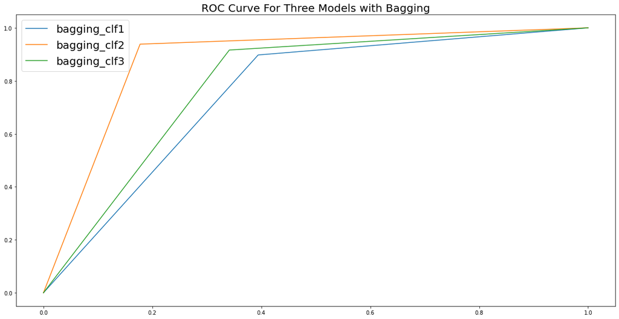

```python
plt.figure(figsize=(20,10))
plt.title("ROC Curve For Three Models with Bagging",size=20)
plt.plot(fper4,tper4,label='bagging_clf1')
plt.plot(fper5,tper5,Label='bagging_clf2')
plt.plot(fper6,tper6,label='bagging_clf3')
plt.legend(prop={'size':20})
plt.show()
```

Compare analysis with three model we use and three model with bagging

```python
A_res=pd.concat([results,results2],ignore_index=True)
```

```python
A_res.set_index('Model')
```

| Model | Train_Accuracy | Test_Accuracy | F1 score | Precision | Recall |
| --- | --- | --- | --- | --- | --- |
| Logistic Regression | 80.0 % | 80.0 % | 86.0 % | 82.0 % | 90.0 % |
| Decision Tree | 99.0 % | 87.0 % | 90.0 % | 90.0 % | 89.0 % |
| SVC | 84.0 % | 83.0 % | 88.0 % | 84.0 % | 92.0 % |
| Bagged Logistic Regression | 80.0 % | 80.0 % | 86.0 % | 82.09 % | 90.0 % |
| Bagged Decision Tree | 99.0 % | 90.0 % | 93.0 % | 91.0 % | 94.0 % |
| Bagged SVC | 84.0 % | 83.0 % | 88.0 % | 84.0 % | 92.0 % |

As we noticed from the above, the decision tree was developed through bagging and made it expect better than the previous one

### Second Way: The soft voting rule for Classification with Three model

```python
vot_clf = VotingClassifier(estimators=[('lr',LogisticRegression()), ('dtc',DecisionTreeClassifier()), ('svc',SVC(probability=True))],voting='soft')
vot_clf.fit(X_train, y_train)
```

```
VotingClassifier(estimators=[('lr', LogisticRegression()),
                             ('dtc', DecisionTreeClassifier()),
                             ('svc', SVC(probability=True))],
                 voting='soft')
```

#### Model Predict

```python
y_pred5=vot_clf.predict(X_test)
print("Original Output: ",y_pred5)
print("Predict Output: ",y_test.values)
```

```
Original Output:  [1 1 1 ... 1 0 0]
Predict Output:  [1 1 1 ... 1 0 0]
```

#### Model Evaluation

```python
print(classification_report(y_test,y_pred5))
```

```
              precision    recall  f1-score   support

           0       0.84      0.76      0.80      3607
           1       0.89      0.93      0.91      7276

    accuracy                           0.87     10883
   macro avg       0.86      0.85      0.85     10883
weighted avg       0.87      0.87      0.87     10883
```

```python
con5=confusion_matrix(y_test,y_pred5)
print("Correct Predict :")
print("_"*30)
print(f"number of True Positive : {con5[0][0]}")
print(f"number of True Negative : {con5[1][1]}")
print("\nIncorrect Predict :")
print("_"*30)
print(f"number of False Positive : {con5[0][1]}")
print(f"number of False Negative : {con5[1][0]}")
```

```
Correct Predict :
______________________________
number of True Positive : 2754
number of True Negative : 6748

Incorrect Predict :
______________________________
number of False Positive : 853
number of False Negative : 528
```

```python
train_acc5=f"{round(bagging_clf.score(X_train,y_train),2)*100} %"
acc5 = f"{round(accuracy_score(y_test,y_pred5),2)*100} %"
f15 = f"{round(f1_score(y_test,y_pred5),2)*100} %"
prec5 = f"{round(precision_score(y_test,y_pred5),2)*100} %"
rec5 =  f"{round(recall_score(y_test,y_pred5),2)*100} %"
results3 = pd.DataFrame([["Soft Voting For Classificatiion",train_acc5, acc5, f15, prec5, rec5]],
                     columns =  ['Model','Train_Accuracy','Test_Accuracy','F1 score','Precision','Recall'])
results3
```

|  | Model | Train_Accuracy | Test_Accuracy | F1 score | Precision | Recall |
| --- | --- | --- | --- | --- | --- | --- |
| 0 | Soft Voting For Classificatiion | 99.0 % | 87.0 % | 91.0 % | 89.0 % | 93.0 % |

show `ROC CURVE` to explain strength of model Soft Voting For Classificatiion

```
<sklearn.metrics._plot.roc_curve.RocCurveDisplay at 0x2820910e190>
```

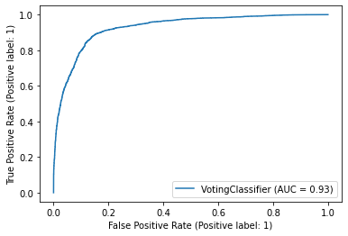

```python
plot_roc_curve(vot_clf,X_test,y_test)
```

This model works well but here is a bit of an overfit

#### Comparative analysis of the created ensemble learning algorithms with the single classifiers

```python
All_Results=pd.concat([results,results2,results3],ignore_index=True)
```

```python
All_Results
```

|  | Model | Train_Accuracy | Test_Accuracy | F1 score | Precision | Recall |
| --- | --- | --- | --- | --- | --- | --- |
| 0 | Logistic Regression | 80.0 % | 80.0 % | 86.0 % | 82.0 % | 90.0 % |
| 1 | Decision Tree | 99.0 % | 87.0 % | 90.0 % | 90.0 % | 89.0 % |
| 2 | SVC | 84.0 % | 83.0 % | 88.0 % | 84.0 % | 92.0 % |
| 3 | Bagged Logistic Regression | 80.0 % | 80.0 % | 86.0 % | 82.09 % | 90.0 % |
| 4 | Bagged Decision Tree | 99.0 % | 90.0 % | 93.0 % | 91.0 % | 94.0 % |
| 5 | Bagged SVC | 84.0 % | 83.0 % | 88.0 % | 84.0 % | 92.0 % |
| 6 | Soft Voting For Classificatiion | 99.0 % | 87.0 % | 91.0 % | 89.0 % | 93.0 % |

# Conclusions

we abled to finish all require like :